# Kaczmarek_Agata_HW2

Agata Kaczmarek

7 04 2021

### Wstęp

W tej pracy skupię się na przygotowaniu dekompozycji predykcji modelu używając narzędzie LIME, a następnie porównam te wyjaśnienia dla różnych obserwacji. Zbiór danych wykorzystany w tym zadaniu dotyczy telefonów i ich różnych cech. Obserwacje posiadające braki w danych zostaną usunięte.

```r
which(is.na(phones))
```

```
##  [1]  992 1011 1058 1097 1130 1198 1229 1234 1391 1400 1406 1413 1420 1425 1432
## [16] 1439 1441 1442 1444 1448 1450 1452 1456 1457 1458 1460 1461 1463 1467 1468
## [31] 1469 1472 1473 1476 1484 1485 1511 1535 1540 1544 1568 1571 1578 1587 1601
## [46] 1612 1619 1630 1639 1643 1645 1646 1648 1654
```

```r
#usuwamy braki
phones2<- phones[complete.cases(phones),]
```

### Model

Poniżej stworzę przykładowy model dla mojego zbioru danych, a także wyliczę jego predykcję dla pięćdziesiątej czwartej obserwacji:

```r
model <- ranger::ranger(price~., data=phones2[,-1], seed=123, num.trees = 50)

model
```

```
## Ranger result
##
## Call:
##  ranger::ranger(price ~ ., data = phones2[, -1], seed = 123, num.trees = 50)
##
## Type:                             Regression
## Number of trees:                  50
## Sample size:                      368
## Number of independent variables:  9
## Mtry:                             3
## Target node size:                 5
## Variable importance mode:         none
## Splitrule:                        variance
## OOB prediction error (MSE):       317170.3
## R squared (OOB):                  0.877379
```

```r
#predykcja dla pierwszego
predict(model, phones2[54,])$predictions
```

```
## [1] 4508.615
```

```r
#dane podane
phones2[54,]$price
```

```
## [1] 4399
```

Różnica jest widoczna między wartością podaną, a wartością wyliczoną przez model, jednak te wartości są dość do siebie zbliżone - wartość podana przez model stanowi około 102.5% wartości podanej.

### Dekompozycja z użyciem LIME

Poniżej wyliczona zostanie dekompozycja predycji modelu dla obserwacji wybranej wyżej:

```r
model_type.dalex_explainer <- DALEXtra::model_type.dalex_explainer
predict_model.dalex_explainer <- DALEXtra::predict_model.dalex_explainer
#explainer
explainer <- DALEX::explain(model = model,
                     data = phones2[,-11],
                     y = phones2$price,
                     colorize = FALSE)
```

```
## Preparation of a new explainer is initiated
##   -> model label       :  ranger  (  default  )
##   -> data              :  368  rows  10  cols
##   -> target variable   :  368  values
##   -> predict function  :  yhat.ranger  will be used (  default  )
##   -> predicted values  :  No value for predict function target column. (  default  )
##   -> model_info        :  package ranger , ver. 0.12.1 , task regression (  default  )
##   -> predicted values  :  numerical, min =  240.4345 , mean =  1768.4 , max =  6837.917
##   -> residual function :  difference between y and yhat (  default  )
##   -> residuals         :  numerical, min =  -753.4092 , mean =  6.586776 , max =  2235.623
##   A new explainer has been created!
```

```r
?predict_surrogate
```

```
## starting httpd help server ... done
```

```r
lime_phones54 <- predict_surrogate(explainer = explainer,
                                  new_observation = phones2[54,-11],
                                 n_features = 7,
                                 n_permutations = 1000,
                                 type = "lime")
plot(lime_phones54)
```

[output not shown]

```r
explainer2<-lime(phones2[,-11], model)
explanation<-explain(phones2[54,-11], explainer2, n_labels=1, n_features=3)
```

Jak widać przy tej obserwacji za trzy najważniejsze zmienne LIME uznał *ram_gb* (wartość większa niż 6), *width_px* (wartość większa niż 1080) oraz *height_px* (wartość większa niż 2400). Wydają to się być dość sensowne założenia, w szczególności to dotyczące pamięci. Różnica między wpływem wartości szerokości oraz wysokości jest zastanawiąjąca, ponieważ są to dwie zmienne, które z przeprowadzonego wcześniej EDA okazały się mocno od siebie zależne, również miały wiele wspólnego z przekątną ekranu, która tutaj nie jest nawet w siedmiu najważniejszych zmiennych.

### Porównanie LIME dla różnych obserwacji

Pierwsza:

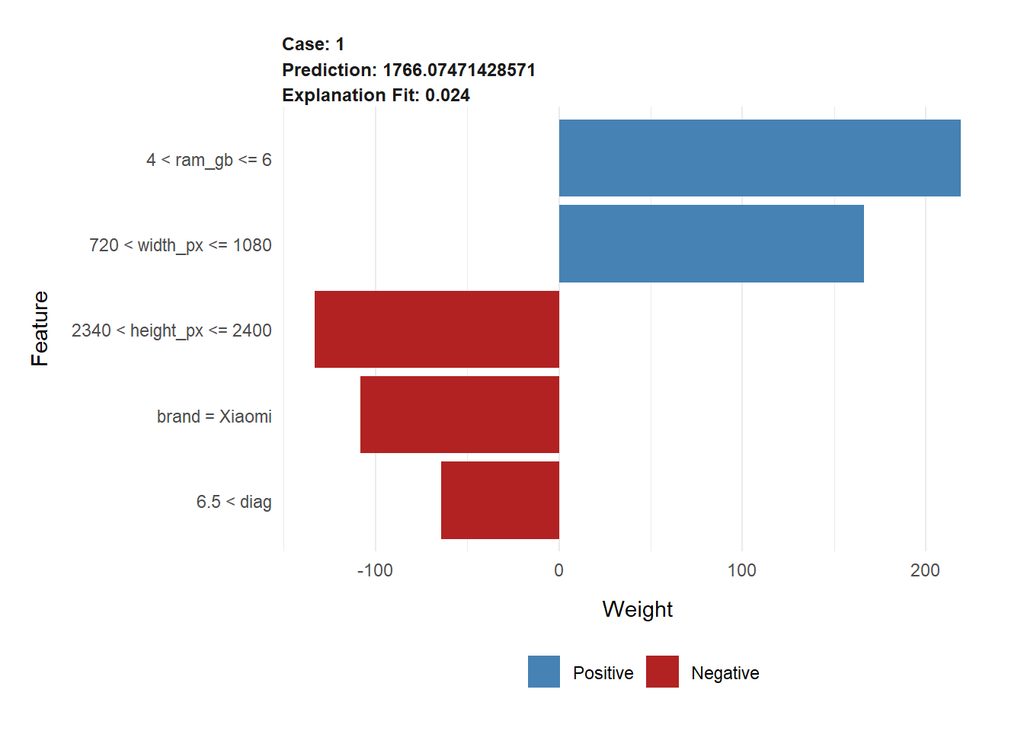

```r
lime_phones1 <- predict_surrogate(explainer = explainer,
                                  new_observation = phones2[1,-11],
                                 n_features = 5,
                                 n_permutations = 1000,
                                 type = "lime")
plot(lime_phones1)
```

Czternasta:

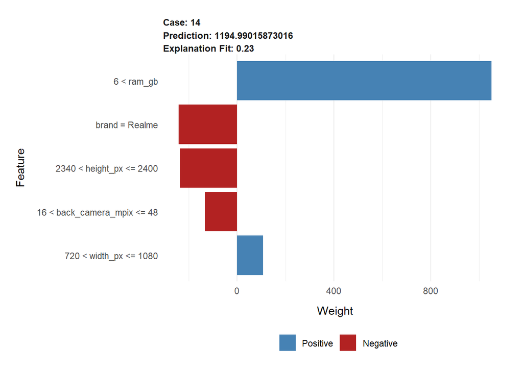

```r
lime_phones14 <- predict_surrogate(explainer = explainer,
                                  new_observation = phones2[14,-11],
                                 n_features = 5,
                                 n_permutations = 1000,
                                 type = "lime")
plot(lime_phones14)
```

Pięćdziesiąta czwarta:

```r
plot(lime_phones54)
```

[output not shown]

[figure not shown]

```r
lime_phones362 <- predict_surrogate(explainer = explainer,
                                  new_observation = phones2[325,-11],
                                 n_features = 5,
                                 n_permutations = 1000,
                                 type = "lime")
plot(lime_phones362)
```

#### Porównanie stabilności otrzymanych wyjaśnień:

Porównując stabilność dla powyższych obserwacji możemy zaobserwować kilka faktów: jeśli *width_px* dla pewnego telefonu było powyżej 720, to mało to wpływ pozytywny na cenę, jeśli poniżej to tak jak w obserwacji 362, miało to negatywny wpływ. Ponadto jeśli wysokość ekranu (*height_px*) była mniejsza niż 2400, to również miało to negatywny wpływ. Takie parametry również w rzeczywistości podwyższają cenę telefonu, więc założenie LIME wydaje się być ok.

Co ciekawe jeśli *front_camera_mpix* ma wartość większą niż 16 lub mniejszą niż 8 ma negatywny wpływ, a jeśli między 8 a 12 to pozytywny. Jednak to nie wydaje się już być do końca rzeczywistym założeniem.

### Porówananie LIME oraz BreakDown lub SHAP

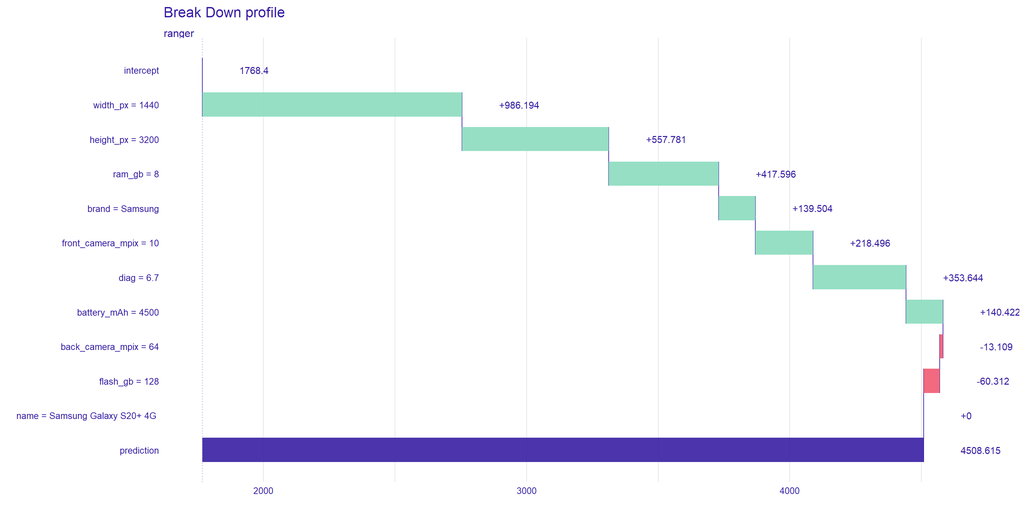

```r
#Break Down
phones2_bd_54 <- predict_parts(explainer,
                            new_observation = phones2[54,])
plot(phones2_bd_54)
```

```r
plot(lime_phones54)
```

[output not shown]

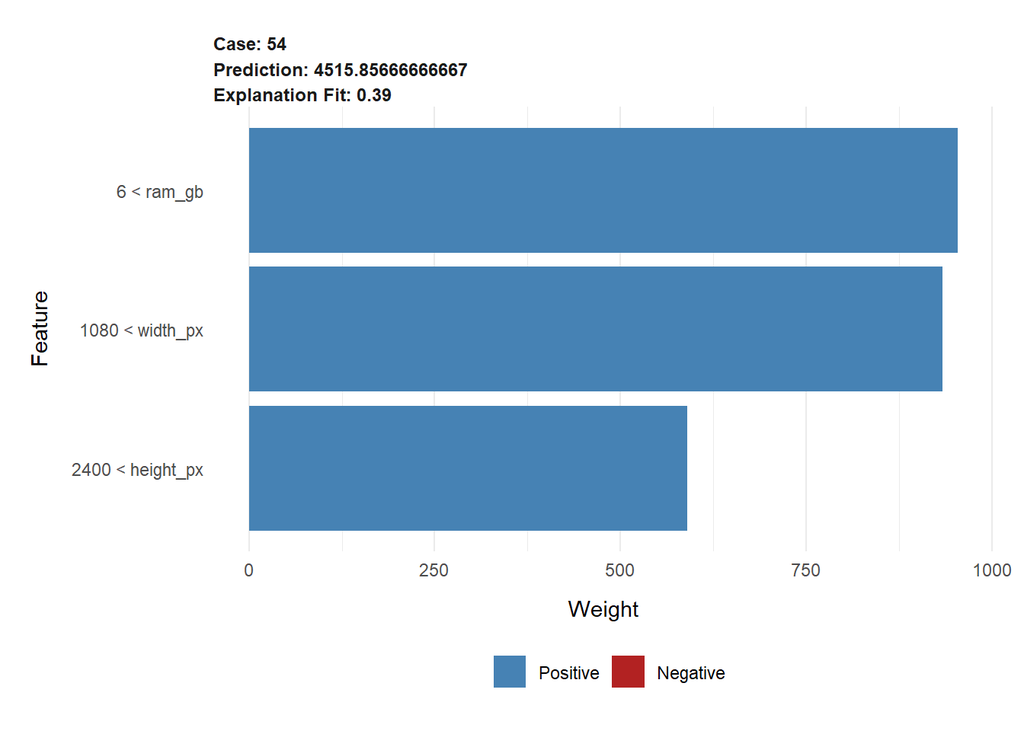

```r
plot_features(explanation)
```

### Wnioski

Powyższe wnioski zostały stworzone na podstawie dekompozycji predykcji dla konkretnych obserwacji, w szczególności wybranych losowo ze zbioru danych. W związku z tym nie mogą być uznane za podstawę do wysnucia globalnych wniosków dla zbioru. Jednak na początku pracy z globalnymi wyjaśnieniami, będzie można spróbować zasugerować się wynikami, które otrzymaliśmy - z użyciem LIME - okazał się on bardziej stabilny niż ostatnio BreakDown. Jednak nawet jeśli postanowimy sugerować się delikatnie wynikami z LIME, to trzeba je bardzie potwierdzić (lub zaprzeczyć im) przy stworzeniu wyjaśnień globalnych używając odpowiednich do tego narzędzi.